# STAT340: Discussion 6: More Hypothesis Testing

Steven Hizmi

02 March, 2021

Link to source file

## Just for fun (1 min)

[figure not shown]

## Exercises

Since we haven’t covered covered estimation yet, today we will explore more exercises relating to hypothesis testing. As usual, break off into **groups of 3-4 students**. In your group, nominate one person to share their screen.

This week, there are **two shorter-ish exercises**, both of which you must complete.

### 1. Gender gap in chess

Due to myriad complex biological factors (e.g. [higher average height](https://doi.org/10.1002/ajpa.1330530314), [higher skeletal muscle mass](https://doi.org/10.1152/jappl.2000.89.1.81), [larger lung sizes](https://dx.doi.org/10.1016%2Fj.tem.2007.08.003), etc.. just to name a few), there continues to be a [*significant gender gap*](https://www.ncbi.nlm.nih.gov/pmc/articles/PMC3761733) in performance in most sports at the top competitive level.

The same gender gap also exists in [games like chess](https://theconversation.com/whats-behind-the-gender-imbalance-in-top-level-chess-150637) where it is less clear why this difference exists. Does the discrepancy mean that men are actually better at chess than women?

Dr. Wei Ji Ma refuted this idea in a [**recent article**](https://en.chessbase.com/post/what-gender-gap-in-chess), arguing that **participation level largely accounts for the observed differences** in ratings of top chess players. Since women are so underrepresented in chess (between $5\%$ and $15\%$ depending on inclusion criteria (location, rating, age, etc.)), there is just simply a much lower chance of having female players who are as good as the top male players (similar to how in a longer sequence of coin flips, there are just more chances of having longer runs than in a shorter sequence).

Using official [ELO rating](https://en.wikipedia.org/wiki/Elo_rating_system) data for Indian players obtained from FIDE (the international governing body for chess), he performed a **permutation test** that showed participation level **can indeed largely account for the observed gender gap**. For this exercise, you will reproduce his results using American players.

1. **Download** a (slightly preprocessed) data frame of the current FIDE standard (tournament) format ELO ratings. Import it normally using `read_csv` (`.csv.gz` just means it’s a [csv that was compressed](https://www.rdocumentation.org/packages/R.utils/versions/1.9.6/topics/gzip) to save space; *you can ignore this* since most functions in *R will automagically decompress and read them*, so no extra work needed), and check it was correctly read by inspecting the first few rows with `head()`.

```r
# DO THIS: uncomment the lines below and complete them
#
ratings.standard = read_csv("chess.csv.gz")
```

```
 # Parsed with column specification:
 # cols(
 #   ID_Number = col_double(),
 #   Name = col_character(),
 #   Sex = col_character(),
 #   Country = col_character(),
 #   B_day = col_double(),
 #   Rating = col_double()
 # )
```

```r
head(ratings.standard)
```

```
 # # A tibble: 6 x 6
 #   ID_Number Name                    Sex   Country       B_day Rating
 #       <dbl> <chr>                   <chr> <chr>         <dbl>  <dbl>
 # 1   1503014 Carlsen, Magnus         M     Norway         1990   2862
 # 2   2020009 Caruana, Fabiano        M     United States  1992   2823
 # 3   4100018 Kasparov, Garry         M     Russia         1963   2812
 # 4   8603677 Ding, Liren             M     China          1992   2791
 # 5   4168119 Nepomniachtchi, Ian     M     Russia         1990   2789
 # 6    623539 Vachier-Lagrave, Maxime M     France         1990   2784
```

2. Ma points out junior players (**born on or after 2000**) may have unreliable ratings. **Remove these players** from the data frame. Also **remove non-US** players, since right now we are interested in analyzing American players.

   Then, **make a density plot** of players’ ratings, showing the **male and female players as separate curves** in the same plot window. Do they look very different?

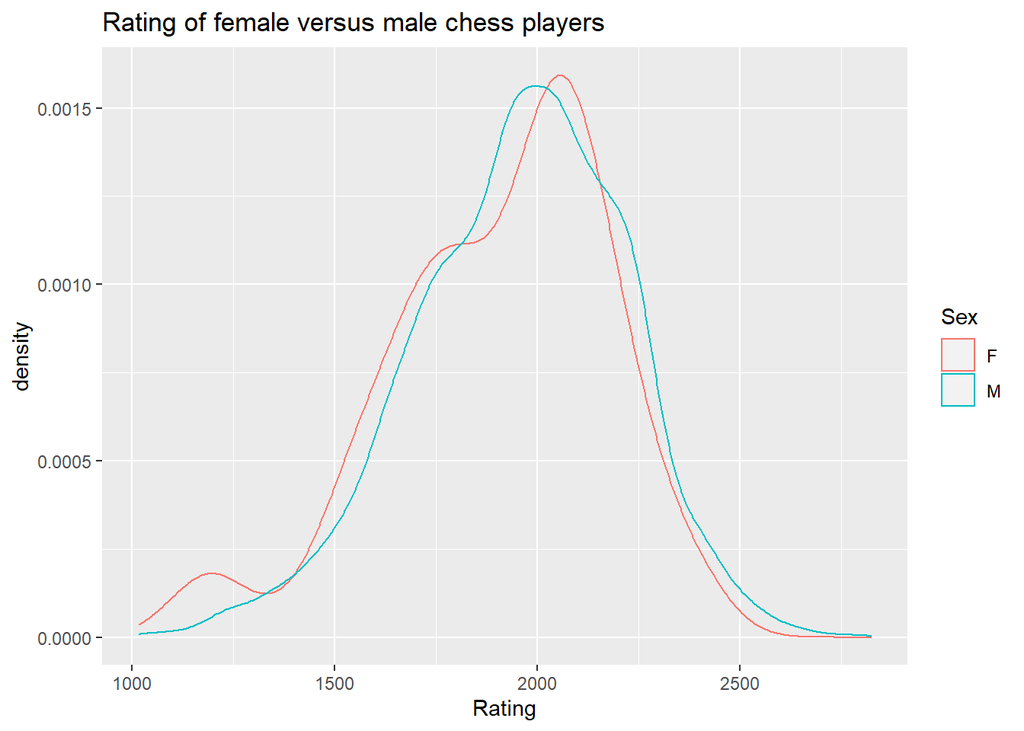

```r
# DO THIS: uncomment lines below and complete them
# note & can be used to filter 2 criteria (bday and country)
#
ratings.standard.us = ratings.standard %>%
  filter(Country == "United States" & B_day < 2000)

ggplot(ratings.standard.us, aes(x= Rating , color=Sex)) + geom_density() +
   ggtitle("Rating of female versus male chess players")
```

```r
# don't forget to add appropriate title/axes!!
```

The ratings aren’t much different, as the male and female curves stay consistent with each other across the graph.They are more similar than they are different.

3. **Make a table** showing the number of players, mean rating, and highest rating for each sex. (**Hint:** this can be easily done in one `dplyr` step; use `group_by` followed by a `summarise` with 3 values).

   What percent of these non-junior American players are women? How many points lower is the rating of the top female American player than the top male?

```r
# DO THIS: uncomment the lines below and complete them
#
ratings.standard.us %>%
  group_by(Sex) %>%
  summarise(num  = n() ,  # for help, see dplyr.tidyverse.org/reference/n.html
            mean = sum(Rating) / n() ,
            max  = max(Rating) )
```

```
 # `summarise()` ungrouping output (override with `.groups` argument)
```

```
 # # A tibble: 2 x 4
 #   Sex     num  mean   max
 #   <chr> <int> <dbl> <dbl>
 # 1 F       205 1905.  2429
 # 2 M      4678 1957.  2823
```

205 / 4,883 = 4.2% of non-junior American players are women.The top rated female player is 394 points below the top rated male player.

4. Let the **null hypothesis** be that there is no actual gender gap in performance, i.e. that **sex does not influence ratings**. Assuming this is true, then we should be able to **permute** the sex column without affecting any observables.

   **Write a function** `permutedMaxSexDiff(df,n)` that, given a data frame `df` and a number of iterations `n`, will for each iteration permute the players’ sexes, recompute the difference in rating between the top male and top female players, and save the result to be returned.

   For efficiency (important in for loops), we implement this as **shuffling the ratings**, then computing
   $$- \max(\text{first $n_F$ elements of permuted ratings}) + \max(\text{rest of ratings vector})$$
   where $n_F$ is the number of female players in the original data frame. Note **this strategy is equivalent** to permuting the player sexes and then computing the difference in each group (in both cases, we’re just randomly choosing $n_F$ values as a group and comparing the maxes of both groups).

```r
# DO THIS: uncomment function below and complete
#

permutedMaxSexDiff = function(df,n){

  # preallocate vector of results
  diffs = rep(NA,n)

  # find number of players to draw in each iteration
  n.F = sum(df$Sex == "F")

  # start loop
  for(i in 1:n){
    # permute ratings
    permuted = sample(df$Rating)

    # find max of first n.F elements of vector
    max.F = max(permuted[1:n.F])

    # find max of rest of vector
    max.M = max(permuted[-1:-n.F])

    # find difference in max ratings and save in results vector
    diffs[i] = -max.F + max.M
  }

  # return results vector
  return(diffs)
}
```

5. Now, **run the function** with at least $N=1000$ iterations (can you do $10,000$?) and visualize the results by **plotting a histogram**. Again, add a vertical line to denote the gender gap in the actual population of non-junior American chess players (top male rating - top female rating).

```
 # `stat_bin()` using `bins = 30`. Pick better value with `binwidth`.
```

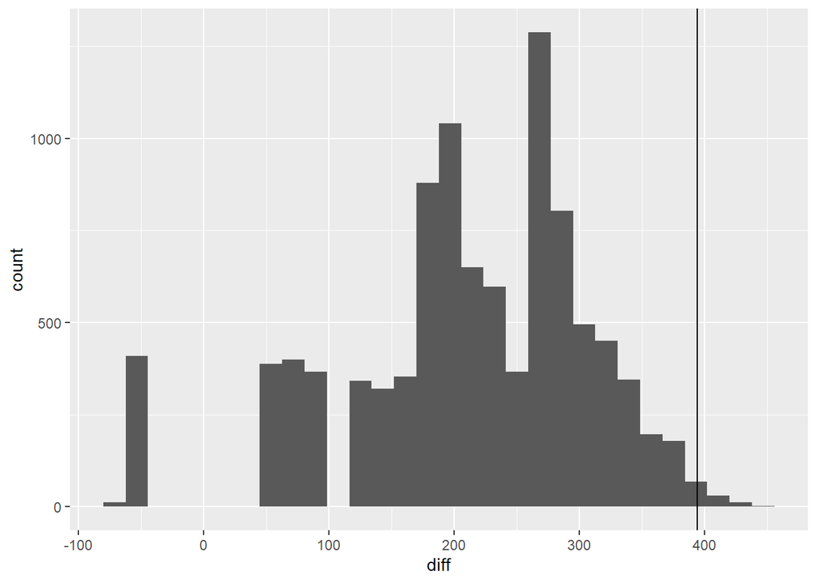

```r
# DO THIS: uncomment the following lines and complete them
true_diff = 394
# # run the function
diffs = permutedMaxSexDiff(ratings.standard.us,10000)

# # use enframe to turn vector into data frame for plotting
diffs %>% enframe(name=NULL, value="diff") %>%
  ggplot(aes(x = diff)) + geom_histogram() +
   geom_vline(xintercept = true_diff )
```

```r
# # compute p-value using mean(), this works since
# # TRUE is numerically treated as 1 and FALSE as 0, and
# # mean is just sum of elements divided by length
pval = mean(diffs > true_diff)
pval
```

```
 # [1] 0.007
```

### 2. Linear regression coefficient testing

To demonstrate the incredible versatility of Monte Carlo methods, we have a second example using the topic of linear regression. (In the future you will see more examples than just permutation tests, but they are extremely well suited to hypothesis testing so we will continue using them for now).

This exercise is written to be simpler than the last one, and should take you less time.

1. Inspect the built-in example data frame `mtcars` that’s loaded with every R session. **Briefly read the help page** by running `?mtcars` if you are unfamiliar with the dataset.

   There are many variables but today we will just focus on **`mpg` (the response variable) and `drat` (a predictor variable)**. Make sure you know what these two variables refer to in real life (see help page!). Create a new data frame called `mtcars.small` with just these two columns and print this new data frame.

```r
### do 2.a here
mtcars.small <- mtcars %>% select(mpg, drat)
mtcars.small
```

```
 #                      mpg drat
 # Mazda RX4           21.0 3.90
 # Mazda RX4 Wag       21.0 3.90
 # Datsun 710          22.8 3.85
 # Hornet 4 Drive      21.4 3.08
 # Hornet Sportabout   18.7 3.15
 # Valiant             18.1 2.76
 # Duster 360          14.3 3.21
 # Merc 240D           24.4 3.69
 # Merc 230            22.8 3.92
 # Merc 280            19.2 3.92
 # Merc 280C           17.8 3.92
 # Merc 450SE          16.4 3.07
 # Merc 450SL          17.3 3.07
 # Merc 450SLC         15.2 3.07
 # Cadillac Fleetwood  10.4 2.93
 # Lincoln Continental 10.4 3.00
 # Chrysler Imperial   14.7 3.23
 # Fiat 128            32.4 4.08
 # Honda Civic         30.4 4.93
 # Toyota Corolla      33.9 4.22
 # Toyota Corona       21.5 3.70
 # Dodge Challenger    15.5 2.76
 # AMC Javelin         15.2 3.15
 # Camaro Z28          13.3 3.73
 # Pontiac Firebird    19.2 3.08
 # Fiat X1-9           27.3 4.08
 # Porsche 914-2       26.0 4.43
 # Lotus Europa        30.4 3.77
 # Ford Pantera L      15.8 4.22
 # Ferrari Dino        19.7 3.62
 # Maserati Bora       15.0 3.54
 # Volvo 142E          21.4 4.11
```

2. Below, I’ve performed a simple linear regression, showing the coefficients. **Take note of the coefficient estimate for the slope $\beta_1$**, which represents the strength of the linear relationship between the two variables (**note** this is NOT the same as *significance*; [see this](https://en.wikipedia.org/wiki/Statistical_significance#Effect_size)).

   One way you can estimate the *significance* of $\beta_1$ (that is usually taught) is to use the linear regression model formulation to derive a [$t$-statistic test](https://www.real-statistics.com/regression/hypothesis-testing-significance-regression-line-slope/) for the coefficients and then compare the estimates to the null hypothesis that $\beta_1=0$, i.e. there is NO linear relationship between the variables. This method has the advantage of possibly higher power at the cost of being more susceptible to heteroscedasticity (among other things).

   You can see from the output below the slope has an estimate of $7.678$ and a standard error of $1.507$. The $t$-statistic is then calculated as $(7.678-0)/1.507=5.096$ which has $n-2=30$ degrees of freedom where $n$ is the number of observations. We can then compute the $p$-value using `2*(1-pt(5.096,30))` and confirm **it matches the table**. (Don’t worry if you don’t fully understand this; however, note the process is almost identical to how you would perform an ordinary $t$-test!)

```r
# DO THIS: uncomment code below and take note of slope estimate
# fist we run lm with mpg regressed on drat,
# data=mtcars.small means use columns from this data frame,
# then run coef() function to extract coefficients from model

summary(lm(mpg ~ drat, data=mtcars.small))$coefficients
```

```
 #              Estimate Std. Error   t value     Pr(>|t|)
 # (Intercept) -7.524618   5.476663 -1.373942 0.1796390847
 # drat         7.678233   1.506705  5.096042 0.0000177624
```

```r
2*(1-pt(5.096042,30))
```

```
 # [1] 1.77624e-05
```

3. Another way you can estimate the significance of $\beta_1$ under the null hypothesis of $\beta_1=0$ is by (you guessed it!) permuting the coordinates! If indeed $\beta_1=0$, then permuting the $x$ coordinates (so they get assigned randomly to the $y$ coordinates) should have no effect (since $\beta_1=0$ implies the relationship is actually a flat line).

   Write a function that performs $n$ iterations of the following:
   1. Randomly permute the $x$ coordinates (`drat` values).
   2. Run linear regression using `lm`.
   3. Save the estimate for the slope of each iteration to be returned.

   Run your function with at least $N=1000$ (can you get it to $10,000$ or even higher?). What is the $p$-value you get from this method?
   - **Note:** If the method in part b. is accurate and the $p$-value is on the order of $10^{-5}$, you may need $10^5=100,000$ iterations to see a single case where the permuted slope is equal to or greater than in absolute value to the actual slope, so if you run a lower $N$ and don’t see a single case, that’s ok, it just means the $p$-value is so small that your simulation size cannot detect it.

```r
### do 2.c here
permutedCoords = function(df,n){

  # preallocate vector of results
  coords = rep(NA,n)

  # start loop
  for(i in 1:n){
    # permute ratings
    permuted = sample(df$drat)

    # run linear regression
    reg = lm(mpg ~ permuted, data=df)$coefficients[8]

    # find difference in max ratings and save in results vector
    coords[i] = reg
  }

  # return results vector
  return(coords)
}

perm = permutedCoords(mtcars.small, 1000)

# Second, write a function to evaluate whether X \in A.
check_if_X_in_A = function(X){
  return(X  >= 7.678)
}

# Now, we are going to do it lots of times.
# Let's arrange the simulations in a data.frame with three columns
r = 10000
monte_carlo = data.frame(replicate = 1:r,
                         X = rep(NA,r),
                         X_in_A = rep(NA, r))
for(i in 1:r){
  monte_carlo$X[i] = perm
  monte_carlo$X_in_A[i] = check_if_X_in_A(monte_carlo$X[i])
}

monte_carlo = as_tibble(monte_carlo)
monte_carlo %>% summarise(mean(X_in_A))
```

```
 # # A tibble: 1 x 1
 #   `mean(X_in_A)`
 #            <dbl>
 # 1             NA
```

## Submission

As usual, make sure the **names of everyone** who worked on this with you is included in the header of this document. Then, **knit this document** and submit **both this file and the HTML output** on Canvas under Assignments ⇒ Discussion 6